# Bikeshare

Fan Shi

11/12/2019

# 1. Introduction

Bike sharing programs are special and potentially game-changing, which can save time while expanding the parts of a city that one can reach quickly and easily. Since bike sharing programe is becoming more and more popular especially in some big cities which suffer from severe congestion, how to get bikes to stations that are anticipated to have demand but lack bikes draws people’s attention.

In this paper, we will build models to predict the trips of the station and thus can help the manager to allocate bikes ahead of time. Because the number of trips in stations is related to weather, location of the station, the demographic factors of people who use the bike as well as the time to use the bike, so we build different models to see which one does a better job and which factors influnence the number of trips in stations. It turned out that the model with temporal, spatial and time lags does the best with the lowest MAE. However, our model still has some problems since some groups seems to be resistent to it and the errors still have spatial pattern.

The code below shows the setup.

```r
library(tidyverse)
library(sf)
library(lubridate)
library(tigris)
library(tidycensus)
library(viridis)
library(riem)
library(gridExtra)
library(knitr)
library(kableExtra)
library(RSocrata)
library(gganimate)
library(gifski)
library(png)

plotTheme <- theme(
  plot.title =element_text(size=12),
  plot.subtitle = element_text(size=8),
  plot.caption = element_text(size = 6),
  axis.text.x = element_text(size = 10, angle = 45, hjust = 1),
  axis.text.y = element_text(size = 10),
  axis.title.y = element_text(size = 10),
  # Set the entire chart region to blank
  panel.background=element_blank(),
  plot.background=element_blank(),
  #panel.border=element_rect(colour="#F0F0F0"),
  # Format the grid
  panel.grid.major=element_line(colour="#D0D0D0",size=.2),
  axis.ticks=element_blank())

mapTheme <- theme(plot.title =element_text(size=12),
                  plot.subtitle = element_text(size=8),
                  plot.caption = element_text(size = 6),
                  axis.line=element_blank(),
                  axis.text.x=element_blank(),
                  axis.text.y=element_blank(),
                  axis.ticks=element_blank(),
                  axis.title.x=element_blank(),
                  axis.title.y=element_blank(),
                  panel.background=element_blank(),
                  panel.border=element_blank(),
                  panel.grid.major=element_line(colour = 'transparent'),
                  panel.grid.minor=element_blank(),
                  legend.direction = "vertical",
                  legend.position = "right",
                  plot.margin = margin(1, 1, 1, 1, 'cm'),
                  legend.key.height = unit(1, "cm"), legend.key.width = unit(0.2, "cm"))

palette5 <- c("#eff3ff","#bdd7e7","#6baed6","#3182bd","#08519c")
palette4 <- c("#D2FBD4","#92BCAB","#527D82","#123F5A")
palette2 <- c("#6baed6","#08519c")
```

# 2. Data Wangling

## 2.1 Import data

The bike share data from April, 2017 to June, 2017 is downloaded from Indego. Since the weather between April and June is relatively comfortable for people to ride bikes, we would have more data, which will help us to find the pattern of both leisure trips and commutes. One should be mentioned is that this range includes one holiday weekend, Memorial Day, which may influence the number of trips.

Also, the demorgraphic data in 2017 is also downloaded using *get_acs*. We will explore the relationship between the social factors and the number of trips in stations later.

```r
#load the phily bike share data from 04/2017-06/2017
ride <- read.csv("G:/upenn/507/bikeshare/indego_gbfs_trips_Q2_2017.csv")

#address the time
dat2 <-
  ride %>%
  mutate(interval60 = floor_date(ymd_hms(start_time), unit = "hour"),
         interval15 = floor_date(ymd_hms(start_time), unit = "15 mins"),
         week = week(interval60),
         dotw = wday(interval60, label=TRUE))

glimpse(dat2)

#import census tract info
tracts17 <-
  get_acs(geography = "tract",
          variables = c("B01003_001", "B19013_001",
                        "B02001_002", "B08013_001",
                        "B08012_001", "B08301_001",
                        "B08301_010", "B01002_001"),
          year = 2017,
          state="PA",
          county=c("Philadelphia"),
          geometry=T,
          output = "wide",
          key='58f0f177458f58fecb4f370dc79e25a7d70c7d51') %>%
  rename(Total_Pop =  B01003_001E,
         Med_Inc = B19013_001E,
         Med_Age = B01002_001E,
         White_Pop = B02001_002E,
         Travel_Time = B08013_001E,
         Num_Commuters = B08012_001E,
         Means_of_Transport = B08301_001E,
         Total_Public_Trans = B08301_010E) %>%
  select(Total_Pop, Med_Inc, White_Pop, Travel_Time,
         Means_of_Transport, Total_Public_Trans,
         Med_Age,
         GEOID, geometry) %>%
  mutate(Percent_White = White_Pop / Total_Pop,
         Mean_Commute_Time = Travel_Time / Total_Public_Trans,
         Percent_Taking_Public_Trans = Total_Public_Trans / Means_of_Transport)

phillyTracts <-
  tracts17 %>%
  as.data.frame() %>%
  distinct(GEOID, .keep_all = TRUE) %>%
  select(GEOID, geometry) %>%
  st_sf
```

```r
#spatial join the data
dat_census <- st_join(dat2 %>%
                        filter(is.na(start_lon) == FALSE &
                                 is.na(start_lat) == FALSE &
                                 is.na(end_lat) == FALSE &
                                 is.na(end_lon) == FALSE) %>%
                        st_as_sf(., coords = c("start_lon", "start_lat"), crs = 4326),
                      phillyTracts %>%
                        st_transform(crs=4326),
                      join=st_intersects,
                      left = TRUE) %>%
  rename(Origin.Tract = GEOID) %>%
  mutate(start_lon = unlist(map(geometry, 1)),
         start_lat = unlist(map(geometry, 2)))%>%
  as.data.frame() %>%
  select(-geometry)%>%
  st_as_sf(., coords = c("end_lon", "end_lat"), crs = 4326) %>%
  st_join(., phillyTracts %>%
            st_transform(crs=4326),
          join=st_intersects,
          left = TRUE) %>%
  rename(Destination.Tract = GEOID)  %>%
  mutate(end_lon = unlist(map(geometry, 1)),
         end_lat = unlist(map(geometry, 2)))%>%
  as.data.frame() %>%
  select(-geometry)
```

Then I use *riem_measures* to download the weather data from April to June, 2017. It is easy to understand that weather condition plays a role in travel mode choice. For example, when it is rainy and snowy outside, people tend not to ride bikes because this may increase the risk factor.

The weather data is shown below. It is obvious that the weather is generally pleasant to ride bikes in Philadelphia from April to June, except on a few days.

```r
#import weather data
weather.Panel <-
  riem_measures(station = "PHL", date_start = "2017-04-01", date_end = "2017-06-30") %>%
  replace(is.na(.), 0) %>%
  mutate(interval60 = ymd_h(substr(valid,1,13))) %>%
  mutate(week = week(interval60),
         dotw = wday(interval60, label=TRUE)) %>%
  group_by(interval60) %>%
  summarize(Temperature = max(tmpf),
            Precipitation = sum(p01i),
            Wind_Speed = max(sknt)) %>%
  mutate(Temperature = ifelse(Temperature == 0, 42, Temperature))
```

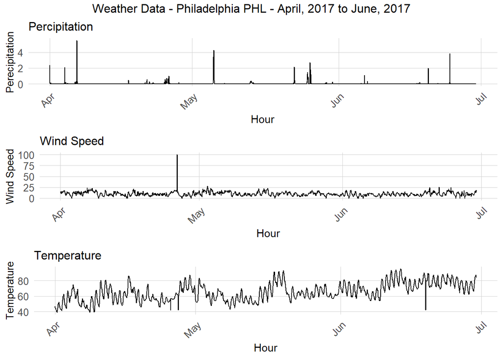

```r
#visualize the weather data
grid.arrange(
  ggplot(weather.Panel, aes(interval60,Precipitation)) + geom_line() +
    labs(title="Percipitation", x="Hour", y="Perecipitation") + plotTheme,
  ggplot(weather.Panel, aes(interval60,Wind_Speed)) + geom_line() +
    labs(title="Wind Speed", x="Hour", y="Wind Speed") + plotTheme,
  ggplot(weather.Panel, aes(interval60,Temperature)) + geom_line() +
    labs(title="Temperature", x="Hour", y="Temperature") + plotTheme,
  top="Weather Data - Philadelphia PHL - April, 2017 to June, 2017")
```

## 2.2 Exploratory Analysis

I create a spatial-temporal panel for the forcast, which has an obervation for every possible space/time combination. This will also be used in explorating data.

```r
#create the space-time panel
study.panel <-
  expand.grid(interval60=unique(dat_census$interval60),
              start_station = unique(dat_census$start_station)) %>%
  left_join(., dat_census %>%
              select(start_station,Origin.Tract, start_lon, start_lat )%>%
              distinct() %>%
              group_by(start_station) %>%
              slice(1))
#create the complete panal
ride.panel <-
  dat_census %>%
  mutate(Trip_Counter = 1) %>%
  right_join(study.panel) %>%
  group_by(interval60, start_station,Origin.Tract, start_lon, start_lat) %>%
  summarize(Trip_Count = sum(Trip_Counter, na.rm=T)) %>%
  left_join(weather.Panel) %>%
  ungroup() %>%
  filter(is.na(start_station) == FALSE) %>%
  mutate(week = week(interval60),
         dotw = wday(interval60, label = TRUE)) %>%
  filter(is.na(Origin.Tract) == FALSE)

ride.panel <-
  left_join(ride.panel, tracts17 %>%
              as.data.frame() %>%
              select(-geometry), by = c("Origin.Tract" = "GEOID"))
```

### 1) temporal structure of data

Firstly, I plot the hourly bike share trips in Philadelphia. Generally, the variation trends of number of trips every month is the same and we can observe a slight increase when we go from April to June.

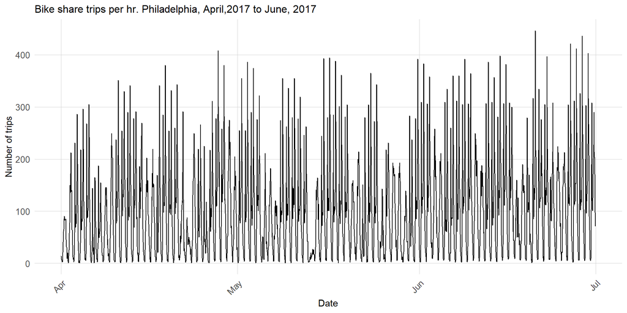

```r
ggplot(dat_census %>%
         group_by(interval60) %>%
         tally())+
  geom_line(aes(x = interval60, y = n))+
  labs(title="Bike share trips per hr. Philadelphia, April,2017 to June, 2017",
       x="Date",
       y="Number of trips")+
  plotTheme
```

Then I plot the mean number of hourly trips per station in different periods of the day. The bike sharing trips mainly concentrated in rush hours in the moring and afternoon.

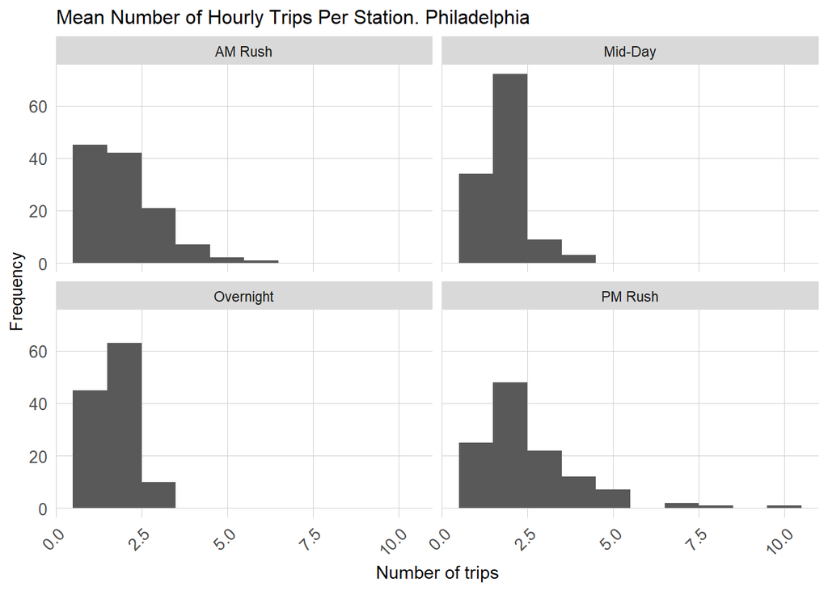

```r
dat_census %>%
  mutate(time_of_day = case_when(hour(interval60) < 7 | hour(interval60) > 18 ~ "Overnight",
                                 hour(interval60) >= 7 & hour(interval60) < 10 ~ "AM Rush",
                                 hour(interval60) >= 10 & hour(interval60) < 15 ~ "Mid-Day",
                                 hour(interval60) >= 15 & hour(interval60) <= 18 ~ "PM Rush"))%>%
  group_by(interval60, start_station, time_of_day) %>%
  tally()%>%
  group_by(start_station, time_of_day)%>%
  summarize(mean_trips = mean(n))%>%
  ggplot()+
  geom_histogram(aes(mean_trips), binwidth = 1)+
  labs(title="Mean Number of Hourly Trips Per Station. Philadelphia",
       x="Number of trips",
       y="Frequency")+
  facet_wrap(~time_of_day)+
  plotTheme
```

The difference of bike sharing trips in weekdays and weekends is explored following the very reasonable hypothesis that people use bikes to commute to work in week days more due to the low cost and time saveings and use less bikes in weekends because they don’t need to follow the strict time laws in the weekdays and thus can choose more commute modes.

From the figure below, it confirms the conclusion we draw before that trips concentrating in rush hours in weekdays. What is more, the number of bike share trips increases first and then decreases from Monday to Friday. In weekend, the peak of bike share trips is about 12pm to 17pm.

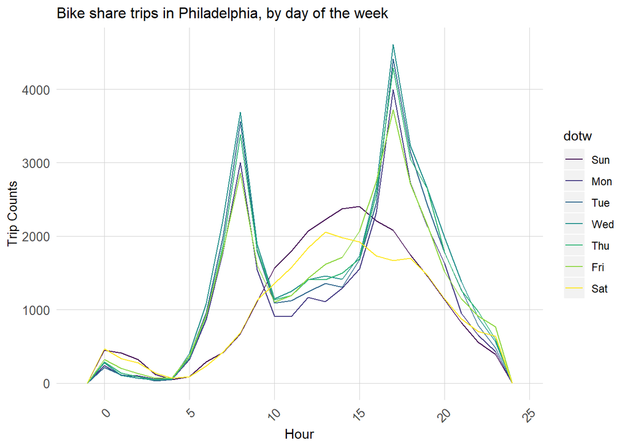

```r
ggplot(dat_census %>% mutate(hour = hour(start_time)))+
  geom_freqpoly(aes(hour, color = dotw), binwidth = 1)+
  labs(title="Bike share trips in Philadelphia, by day of the week",
       x="Hour",
       y="Trip Counts")+
  plotTheme
```

Above, we mainly explore the variation of trips during the week or the day. We will explore the variation of trips in different weeks next. All weeks have similar change trend of bike share trips except week 13, which may due to the cold weather at that time. The Memorial Day is in week 21 and marked using blue line. What surprises us is that the holiday seems to have little influence on the number of bike share trips.

[figure not shown]

```r
as.data.frame(ride.panel) %>%
  group_by(week, interval60) %>%
  summarize(Trip_Count = sum(Trip_Count)) %>%
  ggplot(aes(interval60,Trip_Count)) +
  geom_line() +
  plotTheme +
  facet_wrap(~week, scales="free", ncol=3) +
  ylim(0,400) +
  labs(title="Rideshare trips in Philadelphia by week: April through June, 2017",
       subtitle="Thanksgiving and Christmas in blue", x="Day", y="Trip Counts") +
  geom_vline(xintercept = as.POSIXct("2017-05-27 01:00:00 UTC"),color = "blue",size=1.1)
```

### 2) spacial-temporal structure of data

We have explored the relationship between bike share trips and time series, then we want to check whether there is a spatial pattern of the bike share trips. We create the dynamic plot to show the spatial-temporal pattern of the bike share trips.

Week 20 is chosen to help explore this relationship, which can show the ordinary spatial-temporal pattern of bike share trips for it is not influenced by the holiday and is almost in the middle of the month we choose. It is obvious that bike trips centralized in the central part of Philadelphia, especially the downtown areas.

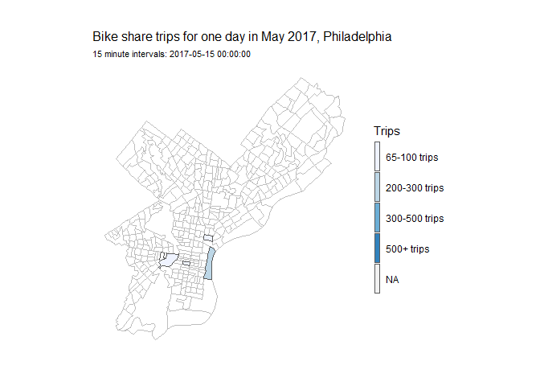

```r
week20 <-
  dat_census %>%
  filter(week == 20 & dotw == "Mon")

week20.panel <-
  expand.grid(
    interval15=unique(week20$interval15),
    Pickup.Census.Tract = unique(week20$Origin.Tract))

ride.animation.data <-
  week20 %>%
  mutate(Trip_Counter = 1) %>%
  right_join(week20.panel) %>%
  group_by(interval15, Origin.Tract) %>%
  summarize(Trip_Count = sum(Trip_Counter, na.rm=T)) %>%
  left_join(tracts17,by=c("Origin.Tract" = "GEOID")) %>%
  st_sf() %>%
  mutate(Trips = case_when(Trip_Count >=65 & Trip_Count <= 100 ~ "65-100 trips",
                           Trip_Count > 200 & Trip_Count <= 300 ~ "200-300 trips",
                           Trip_Count > 300 & Trip_Count <= 500 ~ "300-500 trips",
                           Trip_Count > 500 ~ "500+ trips")) %>%
  mutate(Trips  = factor(Trips, levels=c("65-100 trips","200-300 trips","300-500 trips","500+ trips")))
rideshare_animation <-
  ggplot() +
  geom_sf(data = phillyTracts, color = "grey", fill = "transparent")+
  geom_sf(data=ride.animation.data, aes(fill=Trips)) +
  scale_fill_manual(values = palette5) +
  labs(title = "Bike share trips for one day in May 2017, Philadelphia",
       subtitle = "15 minute intervals: {current_frame}") +
  transition_manual(interval15) +
  mapTheme

animate(rideshare_animation, duration=20)
```

### 3) Relationship between bikeshare and weather

When exploring the relationship between bike share trips and weather conditions, we mainly foucus on three factors: precipitation, temperature and windspeed. The plots below shows the relationship between them.

Generally, demand decreases in rainy or snowy days. However, in week 15 this conculsion no longer applies, perhaps because it rains slight, not heavy enough to prevent people from riding. As temperature goes up, the number of bike share trips increases as well. There seems to have little relationship between windspeed and number of bike share trips since the windspeed is generally below 25 m/s, which does not influence people much.

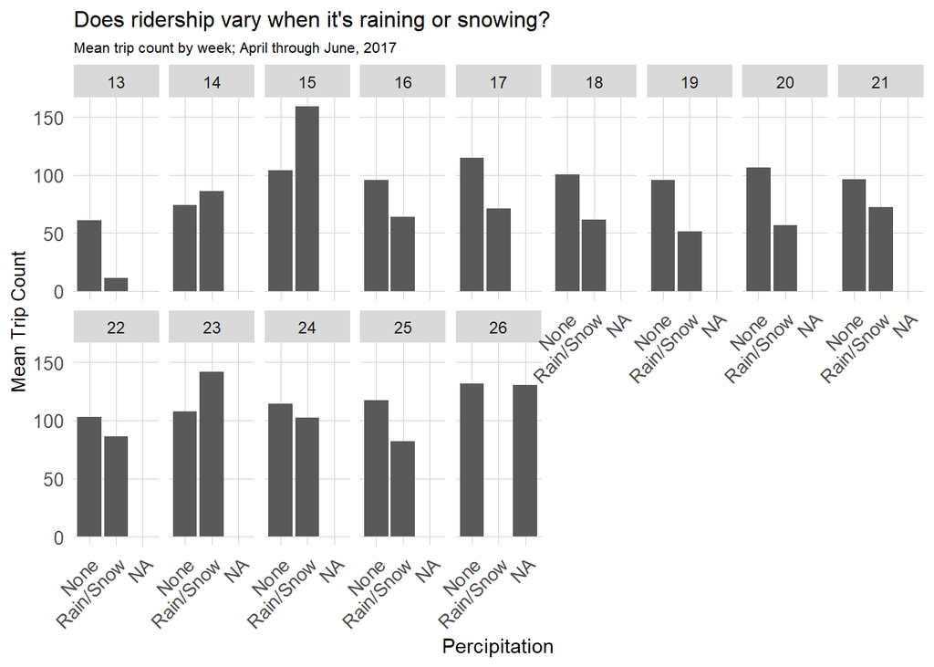

```r
as.data.frame(ride.panel) %>%
  group_by(interval60) %>%
  summarize(Trip_Count = sum(Trip_Count)) %>%
  left_join(weather.Panel) %>%
  mutate(isPercip = ifelse(Precipitation > 0,"Rain/Snow", "None")) %>%
  group_by(week = week(interval60), isPercip) %>%
  summarize(Mean_Trip_Count = mean(Trip_Count)) %>%
  ggplot(aes(isPercip, Mean_Trip_Count)) +
  geom_bar(stat = "identity") +
  facet_wrap(~week,ncol=9) +
  labs(title="Does ridership vary when it's raining or snowing?",
       subtitle="Mean trip count by week; April through June, 2017",
       x="Percipitation", y="Mean Trip Count") +
  plotTheme + theme(axis.text.x = element_text(angle = 45, hjust = 1))
```

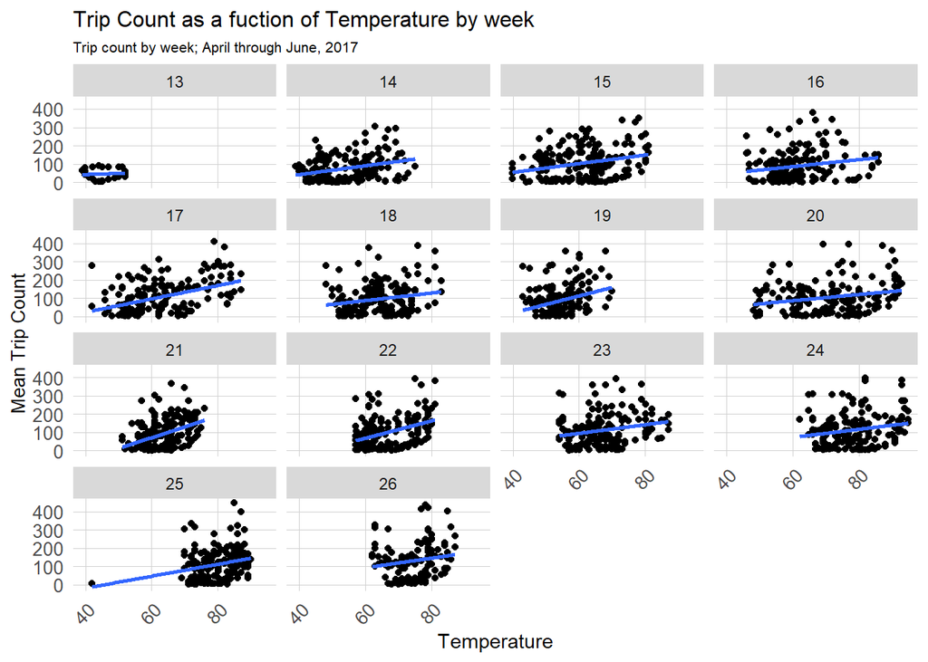

```r
as.data.frame(ride.panel) %>%
  group_by(interval60) %>%
  summarize(Trip_Count = sum(Trip_Count)) %>%
  left_join(weather.Panel) %>%
  mutate(week = week(interval60)) %>%
  ggplot(aes(Temperature, Trip_Count)) +
  geom_point() + facet_wrap(~week) + geom_smooth(method = "lm", se= FALSE) +
  plotTheme +
  labs(title="Trip Count as a fuction of Temperature by week",
       subtitle="Trip count by week; April through June, 2017",
       x="Temperature", y="Mean Trip Count")
```

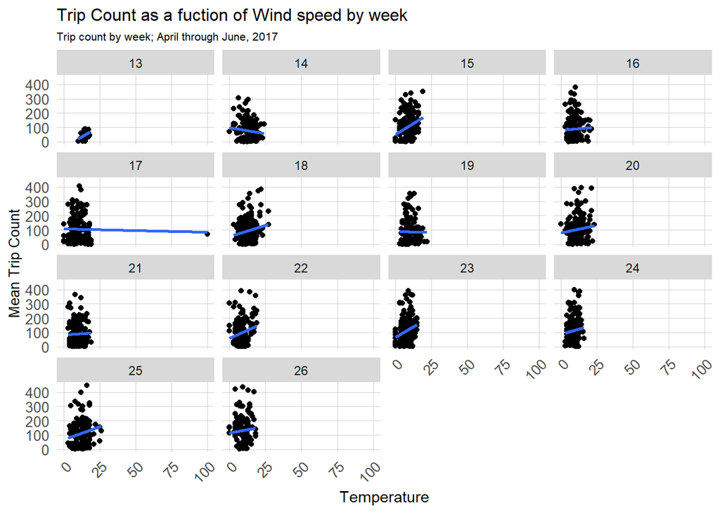

```r
as.data.frame(ride.panel) %>%
  group_by(interval60) %>%
  summarize(Trip_Count = sum(Trip_Count)) %>%
  left_join(weather.Panel) %>%
  mutate(week = week(interval60)) %>%
  ggplot(aes(Wind_Speed, Trip_Count)) +
  geom_point() + facet_wrap(~week) + geom_smooth(method = "lm", se= FALSE) +
  plotTheme +
  labs(title="Trip Count as a fuction of Wind speed by week",
       subtitle="Trip count by week; April through June, 2017",
       x="Temperature", y="Mean Trip Count")
```

### 4) Relationship between bikeshare and social factors

Though we do not use the census demographic factors in our model because of multicollinarity in variables, we still do the exploratory analysis to briefly analyze correlation between them. We take a specific week (week 20) as an example to explore the relationship between bike share trips and four census variables.

We find that as median income, mean commute time and percent of white increase, the number of bike share trips increase. That is, white people with higher income and further work places take bike sharing trips more. However, as the percentage of taking puclic transportations increases, the number of bike share trips decreases, which is easy to understand.

```r
plotData.census <-
  as.data.frame(ride.panel) %>%
  filter(week == 20) %>%
  group_by(Origin.Tract) %>%
  summarize(Trip_Count = sum(Trip_Count))  %>%
  left_join(tracts17, by=c("Origin.Tract" = "GEOID")) %>%
  dplyr::select(Med_Inc,Mean_Commute_Time,Percent_Taking_Public_Trans,Percent_White,Trip_Count) %>%
  gather(Variable, Value, -Trip_Count) %>%
  mutate(Variable = factor(Variable, levels=c("Med_Inc","Mean_Commute_Time","Percent_Taking_Public_Trans","Percent_White")))

correlation.census <-
  plotData.census %>%
  group_by(Variable) %>%
  summarize(correlation = round(cor(Value, Trip_Count),2))

correlation.census
```

```
## # A tibble: 4 x 2
##   Variable                    correlation
##   <fct>                             <dbl>
## 1 Med_Inc                            0.31
## 2 Mean_Commute_Time                  0.24
## 3 Percent_Taking_Public_Trans       -0.4
## 4 Percent_White                      0.38
```

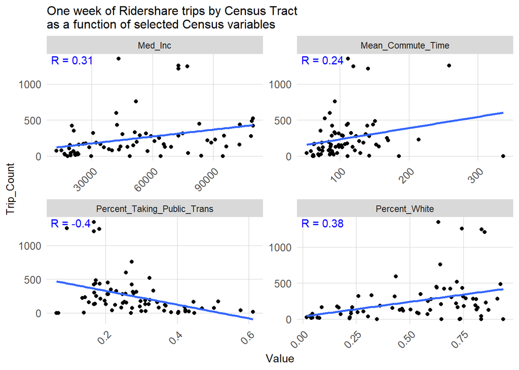

```r
ggplot(plotData.census, aes(Value,Trip_Count)) + geom_point() + geom_smooth(method="lm", se = F) +
  facet_wrap(~Variable, scales="free", ncol=2) +
  geom_text(data=correlation.census, aes(label=paste("R =", correlation)),
            colour = "blue", x=-Inf, y=Inf, hjust=-0.1, vjust=1.2) +
  plotTheme +
  labs(title="One week of Ridershare trips by Census Tract\nas a function of selected Census variables")
```

### 5) Relationship between time lag and bikeshare

From the analysis above, it is obvious that bike share trips are influenced by time series. Then we create the time lags to see whether they have relationships with bike share trips, similar to what we have done in predicting the house prices.

*Trip_Count* as a function of the various time lags are then visualized below. These effects are very strong. Note that the correlation decreases with each additional hour, however, the predictive power returns with the 24 hour lag.

One holiday fixed effects is also created for Memorial Day with the hypothesis that ride share patterns will certainly change around national holidays. Though from the figure in data wrangling section we don’t find much difference, we keep it in the model to see whether it can improve the model.

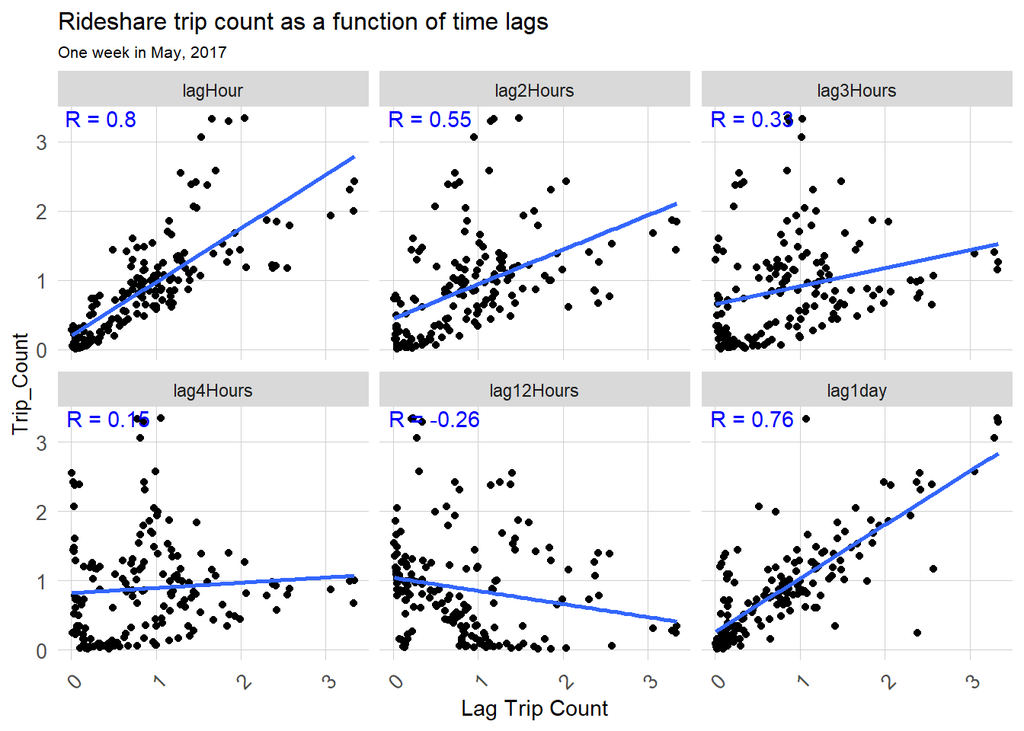

```r
ride.panel <-
  ride.panel %>%
  arrange(start_station, interval60) %>%
  mutate(lagHour = dplyr::lag(Trip_Count,1),
         lag2Hours = dplyr::lag(Trip_Count,2),
         lag3Hours = dplyr::lag(Trip_Count,3),
         lag4Hours = dplyr::lag(Trip_Count,4),
         lag12Hours = dplyr::lag(Trip_Count,12),
         lag1day = dplyr::lag(Trip_Count,24),
         holiday = ifelse(yday(interval60) == 148,1,0)) %>%
  mutate(day = yday(interval60)) %>%
  mutate(holidayLag = case_when(dplyr::lag(holiday, 1) == 1 ~ "PlusOneDay",
                                dplyr::lag(holiday, 2) == 1 ~ "PlustTwoDays",
                                dplyr::lag(holiday, 3) == 1 ~ "PlustThreeDays",
                                dplyr::lead(holiday, 1) == 1 ~ "MinusOneDay",
                                dplyr::lead(holiday, 2) == 1 ~ "MinusTwoDays",
                                dplyr::lead(holiday, 3) == 1 ~ "MinusThreeDays"),
         holidayLag = replace_na(holidayLag, 0))

plotData.lag <-
  as.data.frame(ride.panel) %>%
  filter(week == 20) %>%
  group_by(interval60) %>%
  summarise_at(vars(starts_with("lag"), "Trip_Count"), mean, na.rm = TRUE) %>%
  gather(Variable, Value, -interval60, -Trip_Count) %>%
  mutate(Variable = factor(Variable, levels=c("lagHour","lag2Hours","lag3Hours","lag4Hours",
                                              "lag12Hours","lag1day")))

correlation.lag <-
  as.data.frame(ride.panel) %>%
  group_by(interval60) %>%
  summarise_at(c("lagHour","lag2Hours","lag3Hours","lag4Hours","lag12Hours","lag1day", "Trip_Count"), mean, na.rm = TRUE) %>%
  gather(Variable, Value, -interval60, -Trip_Count) %>%
  mutate(Variable = factor(Variable, levels=c("lagHour","lag2Hours","lag3Hours","lag4Hours",
                                              "lag12Hours","lag1day")))%>%
  group_by(Variable) %>%
  summarize(correlation = round(cor(Value, Trip_Count),2))

plotData.lag %>%
  ggplot(aes(Value, Trip_Count)) +
  geom_point() + geom_smooth(method = "lm", se = F) +
  facet_wrap(~Variable) +
  geom_text(data=correlation.lag, aes(label=paste("R =", correlation)),colour = "blue",
            x=-Inf, y=Inf, hjust=-0.1, vjust=1.2) +
  labs(title = "Rideshare trip count as a function of time lags",
       subtitle= "One week in May, 2017", x = "Lag Trip Count") +
  plotTheme
```

# 3. Build the model

## 3.1 Run the model

We split the data into a training and a test set. Because of the complexity to do cross-validation, we just split the data subjectively. Additionaly, the reason why I use the latter weeks to predict the former weeks is that only the latter weeks contain the holiday and the training set should contain all possible values of the predictors.

```r
ride.Train <- filter(ride.panel, week >=18)
ride.Test <- filter(ride.panel, week <18)
```

Five OLS regressions are built, and a breakdown of the 5 regressions is estimated below:

1.The first focuses on just time effects. reg1 includes hour fixed effects, day of the week fixed effects, Precipitation and Temperature. Lag effects are not included for now.

2.reg2, replaces the time fixed effects with a vector of Origin.Tract fixed effects,indicating the spatial effects.

3.reg3 includes both time and space fixed effects.

4.reg4 adds the time lag features.

5.reg5 adds holiday and holidayLag effects.

```r
reg1 <-
  lm(Trip_Count ~  hour(interval60) + dotw + Temperature+ Precipitation,  data=ride.Train)

reg2 <-
  lm(Trip_Count ~  Origin.Tract + dotw + Temperature + Precipitation,  data=ride.Train)

reg3 <-
  lm(Trip_Count ~  Origin.Tract + hour(interval60) + dotw + Temperature + Precipitation,
     data=ride.Train)

reg4 <-
  lm(Trip_Count ~  Origin.Tract +  hour(interval60) + dotw + Temperature + Precipitation +
       lagHour + lag2Hours +lag3Hours + lag12Hours + lag1day,
     data=ride.Train)

reg5 <-
  lm(Trip_Count ~  Origin.Tract + hour(interval60) + dotw + Temperature + Precipitation +
       lagHour + lag2Hours +lag3Hours +lag12Hours + lag1day + holidayLag + holiday,
     data=ride.Train)
```

## 3.2 Predictions in the test data

Then we create a nested data frame of test dat by week and make the predictin in test data.

```r
ride.Test.weekNest <-
  ride.Test %>%
  nest(-week)

model_pred <- function(dat, fit){
  pred <- predict(fit, newdata = dat)
  }

week_predictions <-
  ride.Test.weekNest %>%
  mutate(ATime_FE = map(.x = data, fit = reg1, .f = model_pred),
         BSpace_FE = map(.x = data, fit = reg2, .f = model_pred),
         CTime_Space_FE = map(.x = data, fit = reg3, .f = model_pred),
         DTime_Space_FE_timeLags = map(.x = data, fit = reg4, .f = model_pred),
         ETime_Space_FE_timeLags_holidayLags = map(.x = data, fit = reg5, .f = model_pred)) %>%
  gather(Regression, Prediction, -data, -week) %>%
  mutate(Observed = map(data, pull, Trip_Count),
         Absolute_Error = map2(Observed, Prediction,  ~ abs(.x - .y)),
         MAE = map_dbl(Absolute_Error, mean, na.rm = TRUE),
         sd_AE = map_dbl(Absolute_Error, sd, na.rm = TRUE))

week_predictions
```

```
## # A tibble: 25 x 8
##     week          data Regression Prediction Observed Absolute_Error   MAE
##    <dbl> <list<df[,29> <chr>      <list>     <list>   <list>         <dbl>
##  1    13  [2,832 x 29] ATime_FE   <dbl [2,8~ <dbl [2~ <dbl [2,832]>  0.626
##  2    14 [19,588 x 29] ATime_FE   <dbl [19,~ <dbl [1~ <dbl [19,588]> 0.901
##  3    15 [19,706 x 29] ATime_FE   <dbl [19,~ <dbl [1~ <dbl [19,706]> 1.05
##  4    16 [19,824 x 29] ATime_FE   <dbl [19,~ <dbl [1~ <dbl [19,824]> 0.976
##  5    17 [19,470 x 29] ATime_FE   <dbl [19,~ <dbl [1~ <dbl [19,470]> 1.07
##  6    13  [2,832 x 29] BSpace_FE  <dbl [2,8~ <dbl [2~ <dbl [2,832]>  0.601
##  7    14 [19,588 x 29] BSpace_FE  <dbl [19,~ <dbl [1~ <dbl [19,588]> 0.824
##  8    15 [19,706 x 29] BSpace_FE  <dbl [19,~ <dbl [1~ <dbl [19,706]> 0.977
##  9    16 [19,824 x 29] BSpace_FE  <dbl [19,~ <dbl [1~ <dbl [19,824]> 0.899
## 10    17 [19,470 x 29] BSpace_FE  <dbl [19,~ <dbl [1~ <dbl [19,470]> 0.989
## # ... with 15 more rows, and 1 more variable: sd_AE <dbl>
```

# 4. Space-time error validation

We use the MAE to judge the goodness of fit of the model. Here, we plot the MAE by model specification and week to see how well the five models does in the test data and the difference between different weeks.

Generally, five models have done a good job since we have a MAE under or around 1, indicating that we have a good overall accuracy. However, the time lag effects add a tremendous amount of predictive power to this model. Not surprisingly, ride share patterns from the very recent past do a great job predicting in the near future.

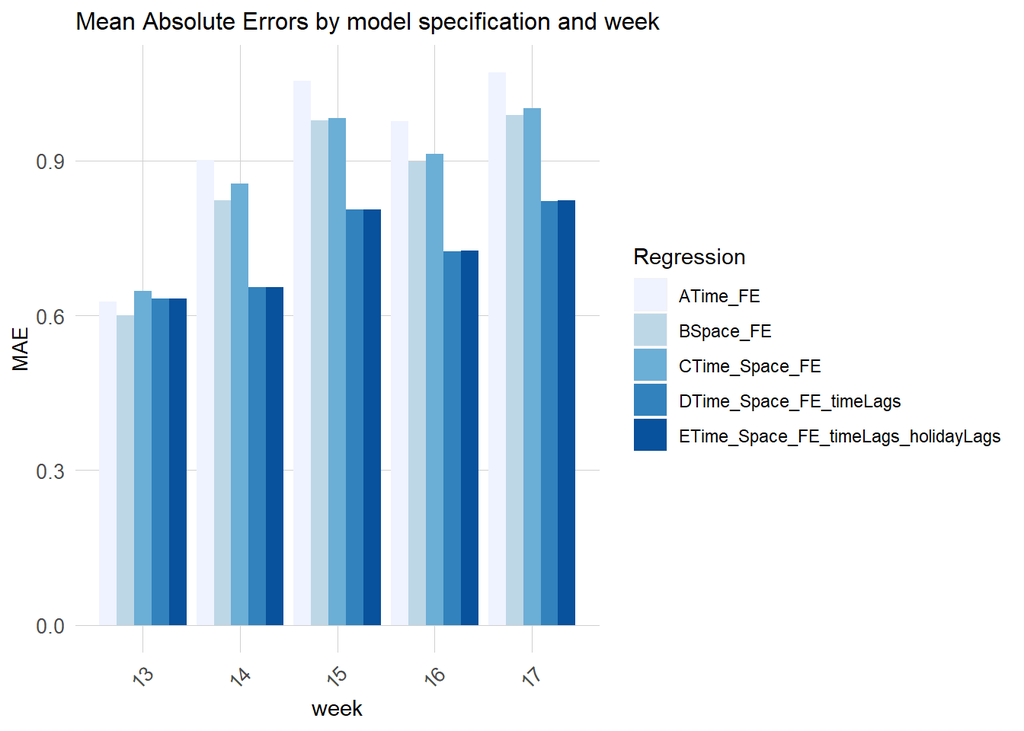

```r
week_predictions %>%
  dplyr::select(week, Regression, MAE) %>%
  gather(Variable, MAE, -Regression, -week) %>%
  ggplot(aes(week, MAE)) +
  geom_bar(aes(fill = Regression), position = "dodge", stat="identity") +
  scale_fill_manual(values = palette5) +
  labs(title = "Mean Absolute Errors by model specification and week") +
  plotTheme
```

Comparison between predicted bike share trips and observed bike share trips in time series is also done and the figure is shown below. Model D and Model E which contain the time lags do the best above 5 models, but still underestimate the bike share trips spikes overall.It is also clear that the spatial fixed effects alone don’t help predict the time trend because model A and C appear to have the same time trends. Model B seems to do the worst even though it has lower overall MAE than model A and C, it misses almost all the spikes.

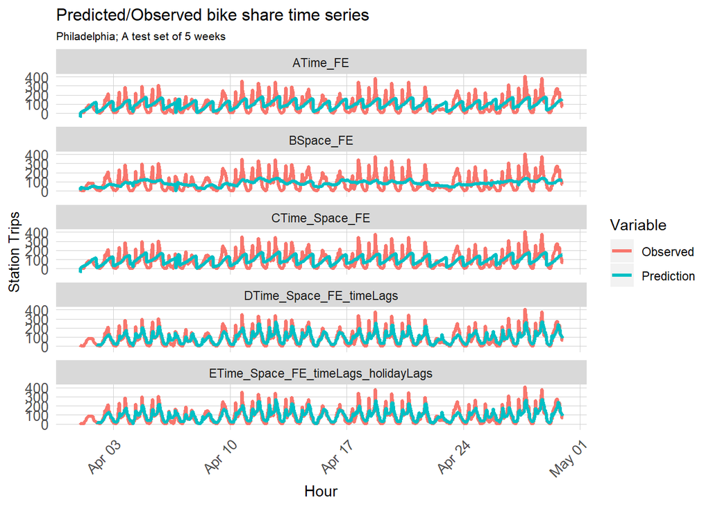

```r
week_predictions %>%
  mutate(interval60 = map(data, pull, interval60),
         start_station = map(data, pull, start_station)) %>%
  dplyr::select(interval60, start_station, Observed, Prediction, Regression) %>%
  unnest() %>%
  gather(Variable, Value, -Regression, -interval60, -start_station) %>%
  group_by(Regression, Variable, interval60) %>%
  summarize(Value = sum(Value)) %>%
  ggplot(aes(interval60, Value, colour=Variable)) +
  geom_line(size = 1.1) +
  facet_wrap(~Regression, ncol=1) +
  labs(title = "Predicted/Observed bike share time series", subtitle = "Philadelphia; A test set of 5 weeks",  x = "Hour", y= "Station Trips") +
  plotTheme
```

Since the fifth model seems to have the best goodness of fit generally, though the difference between model D and E is nuanced, we stick with *reg5* to see whether the MAE by station has spatial patterns. The figure is plotted below.

Generally, the closer the stations to the central Philadelphia, the larger the MAE by station is.

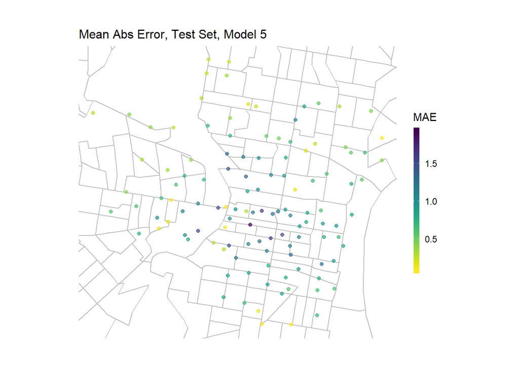

```r
week_predictions %>%
  mutate(interval60 = map(data, pull, interval60),
         start_station = map(data, pull, start_station),
         start_lat = map(data, pull, start_lat),
         start_lon = map(data, pull, start_lon)) %>%
  select(interval60, start_station, start_lon, start_lat, Observed, Prediction, Regression) %>%
  unnest() %>%
  filter(Regression == "ETime_Space_FE_timeLags_holidayLags") %>%
  group_by(start_station, start_lon, start_lat) %>%
  summarize(MAE = mean(abs(Observed-Prediction), na.rm = TRUE))%>%
  ggplot(.)+
  geom_sf(data = phillyTracts, color = "grey", fill = "transparent")+
  geom_point(aes(x = start_lon, y = start_lat, color = MAE),
             fill = "transparent", alpha = 0.7)+
  scale_colour_viridis(direction = -1,
                       discrete = FALSE, option = "D")+
  ylim(min(dat_census$start_lat), max(dat_census$start_lat))+
  xlim(min(dat_census$start_lon), max(dat_census$start_lon))+
  labs(title="Mean Abs Error, Test Set, Model 5")+
  mapTheme
```

Then we are going to get the temporal element of the error. We compare the observed bike share trips and the predicted bike share trips for different time periods of the day during the week and weekend. The figure is plotted below.

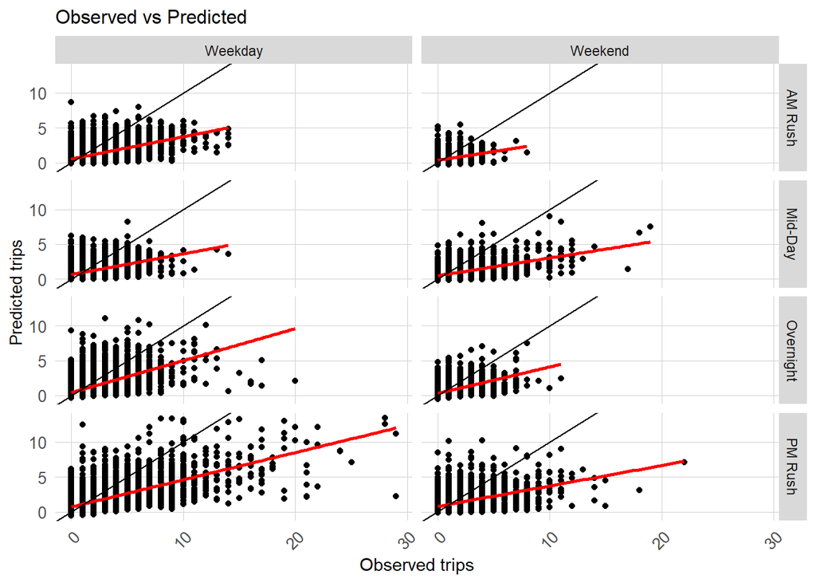

```r
week_predictions %>%
  mutate(interval60 = map(data, pull, interval60),
         start_station = map(data, pull, start_station),
         start_lat = map(data, pull, start_lat),
         start_lon = map(data, pull, start_lon),
         dotw = map(data, pull, dotw)) %>%
  select(interval60, start_station, start_lon,
         start_lat, Observed, Prediction, Regression,
         dotw) %>%
  unnest() %>%
  filter(Regression == "ETime_Space_FE_timeLags_holidayLags")%>%
  mutate(weekend = ifelse(dotw %in% c("Sun", "Sat"), "Weekend", "Weekday"),
         time_of_day = case_when(hour(interval60) < 7 | hour(interval60) > 18 ~ "Overnight",
                                 hour(interval60) >= 7 & hour(interval60) < 10 ~ "AM Rush",
                                 hour(interval60) >= 10 & hour(interval60) < 15 ~ "Mid-Day",
                                 hour(interval60) >= 15 & hour(interval60) <= 18 ~ "PM Rush"))%>%
  ggplot()+
  geom_point(aes(x= Observed, y = Prediction))+
  geom_smooth(aes(x= Observed, y= Prediction), method = "lm", se = FALSE, color = "red")+
  geom_abline(slope = 1, intercept = 0)+
  facet_grid(time_of_day~weekend)+
  labs(title="Observed vs Predicted",
       x="Observed trips",
       y="Predicted trips")+
  plotTheme
```

Before, we check the spatial pattern of MAE by station, ignoring the time factors. Thus, in order to find the spatial pattern of MAE in different time periods during week and weekend, we plot the figure below.

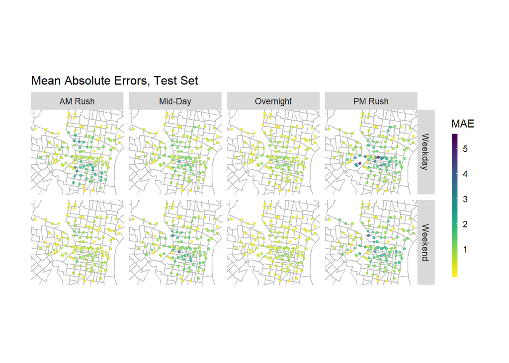

```r
week_predictions %>%
  mutate(interval60 = map(data, pull, interval60),
         start_station = map(data, pull, start_station),
         start_lat = map(data, pull, start_lat),
         start_lon = map(data, pull, start_lon),
         dotw = map(data, pull, dotw) ) %>%
  select(interval60, start_station, start_lon,
         start_lat, Observed, Prediction, Regression,
         dotw) %>%
  unnest() %>%
  filter(Regression == "ETime_Space_FE_timeLags_holidayLags")%>%
  mutate(weekend = ifelse(dotw %in% c("Sun", "Sat"), "Weekend", "Weekday"),
         time_of_day = case_when(hour(interval60) < 7 | hour(interval60) > 18 ~ "Overnight",
                                 hour(interval60) >= 7 & hour(interval60) < 10 ~ "AM Rush",
                                 hour(interval60) >= 10 & hour(interval60) < 15 ~ "Mid-Day",
                                 hour(interval60) >= 15 & hour(interval60) <= 18 ~ "PM Rush")) %>%
  group_by(start_station, weekend, time_of_day, start_lon, start_lat) %>%
  summarize(MAE = mean(abs(Observed-Prediction), na.rm = TRUE))%>%
  ggplot(.)+
  geom_sf(data = phillyTracts, color = "grey", fill = "transparent")+
  geom_point(aes(x = start_lon, y = start_lat, color = MAE),
             fill = "transparent", size = 1, alpha = 0.7)+
  scale_colour_viridis(direction = -1,
                       discrete = FALSE, option = "D")+
  ylim(min(dat_census$start_lat), max(dat_census$start_lat))+
  xlim(min(dat_census$start_lon), max(dat_census$start_lon))+
  facet_grid(weekend~time_of_day)+
  labs(title="Mean Absolute Errors, Test Set")+
  mapTheme
```

When we set errors as a function of socio-economic variables, we find that our model does bad in stations where the percentage of white is high and the public transit usage is low. Age of residents seems to have litte relatinship with the errors.

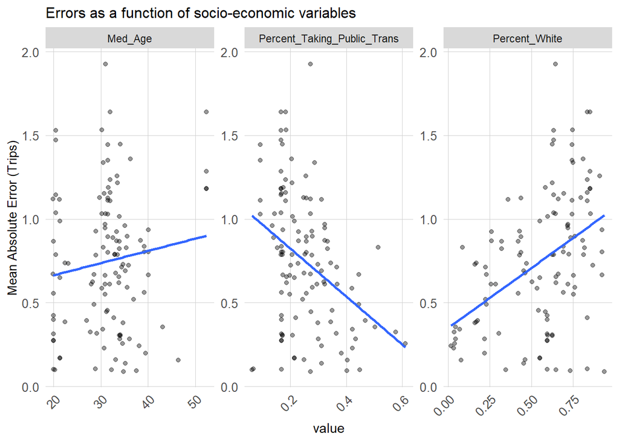

```r
week_predictions %>%
  mutate(interval60 = map(data, pull, interval60),
         start_station = map(data, pull, start_station),
         start_lat = map(data, pull, start_lat),
         start_lon = map(data, pull, start_lon),
         dotw = map(data, pull, dotw),
         Percent_Taking_Public_Trans = map(data, pull, Percent_Taking_Public_Trans),
         Med_Age = map(data, pull, Med_Age),
         Percent_White = map(data, pull, Percent_White)) %>%
  select(interval60, start_station, start_lon,
         start_lat, Observed, Prediction, Regression,
         dotw, Percent_Taking_Public_Trans, Med_Age, Percent_White) %>%
  unnest() %>%
  filter(Regression == "ETime_Space_FE_timeLags_holidayLags")%>%
  group_by(start_station, Percent_Taking_Public_Trans, Med_Age, Percent_White) %>%
  summarize(MAE = mean(abs(Observed-Prediction), na.rm = TRUE))%>%
  gather(-start_station, -MAE, key = "variable", value = "value")%>%
  ggplot(.)+
  geom_point(aes(x = value, y = MAE), alpha = 0.4)+
  geom_smooth(aes(x = value, y = MAE), method = "lm", se= FALSE)+
  facet_wrap(~variable, scales = "free")+
  labs(title="Errors as a function of socio-economic variables",
       y="Mean Absolute Error (Trips)")+
  plotTheme
```

# 5. Conclusion

Based on our time-series plots, we can see that we are able to track the time components of demand, but we miss the peaks, and underpredict for periods of high demand, which may result in lack of bycicles in high demand areas. In this paper, spatial patterns still remain in errors, indicating that we still have some issues with spatial autocorrelation. Perhaps we can add spatial lags in the model to better illustrate the spatial structure of the data. When we set errors as a function of socio-economic variables, it shows that we don’t predict well in certain groups, which may be improved by adding new features like the gender of the person who rides the bike, the travel time of the trips, etc.